# Bioinformatics HW 4

Ryan Gallagher

2023-10-27

## 1) Download and read in a data package “golubEsets” into R. Read in the dataset “Golub_Merge”. This is a leukemia dataset.

### a) How many genes and how many samples are in the data set? How many acute lymphoblastic leukemia (ALL) patients and how many acute myeloid leukemia (ALM) patients in the dataset? How many male, female, and unknown patients?

- There are 7129 genes in the dataset.
- There are 72 samples in the dataset.
- There are 47 patients with acute lymphoblastic leukemia (ALL)
- There are 25 patients with acute myeloid leukemia (AML)
- Gender is distributed as: 23, 26
- With ‘NA’ accounting for 23

```r
table(Golub_Merge$Gender)
```

```
##
##  F  M
## 23 26
```

### b) Use all genes and do dimension redution PCA. Color ALL and AML patients on the plot.

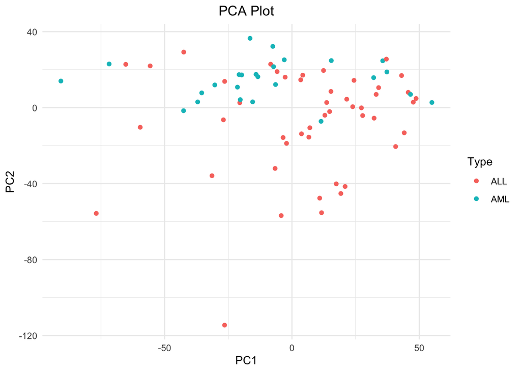

```r
pheno_data = pData(Golub_Merge)
expression_mat = exprs(Golub_Merge)

pca = prcomp(t(expression_mat), scale.=TRUE)

pca_dat = data.frame(PC1 = pca$x[,1],
                     PC2 = pca$x[,2],
                     Type = factor(pheno_data$ALL.AML))

ggplot(pca_dat, aes(x=PC1, PC2, color=Type)) + geom_point() +
  theme_minimal() +
  labs(title="PCA Plot", x="PC1", y="PC2", color="Type") +
  theme(plot.title = element_text(hjust=0.5))
```

### c) Use “samr” package in R to detect differentially expressed genes (use random seed 12345) between ALL and AML patients. You will have the read the document from the package to learn how to use the function correctly. How many ALL up-regulated and down-regulated genes are identified when FDR threshold is 5%? How about when FDR is 1%? List the top 10 up-regulated and down-regulared DE genes respectively. Plot a heatmap for identified DE genes at 1% threshold.

```r
#install.packages('samr')
library(samr)
set.seed(12345)
class_vec = factor(pData(Golub_Merge)$ALL.AML)

sam_dat = list(x = expression_mat,
               y = class_vec,
               logged2=TRUE)

samr_o = samr(data = sam_dat,
              resp.type = "Two class unpaired",
              nperms = 100)
```

```r
delta.table = samr.compute.delta.table(samr_o)
siggenes.table = samr.compute.siggenes.table(samr_o, 0.05, sam_dat, delta.table)

low_tab = as.data.frame(siggenes.table$genes.lo)
low_tab = low_tab %>% mutate(score = as.numeric(`Score(d)`)) %>% arrange(score)
high_tab = as.data.frame(siggenes.table$genes.up)
high_tab = high_tab %>% mutate(score = as.numeric(`Score(d)`)) %>% arrange(desc(score))

up = siggenes.table$ngenes.up
lo = siggenes.table$ngenes.lo
```

Top 10 up_regulated

```r
head(high_tab$`Gene ID`, 10)
```

```
##  [1] "g4847" "g4196" "g2288" "g1882" "g1834" "g6041" "g3252" "g2121" "g1745"
## [10] "g1829"
```

Top 10 down-regulared

```r
head(low_tab$`Gene ID`, 10)
```

```
##  [1] "g4328" "g2354" "g6855" "g2642" "g6225" "g6281" "g804"  "g1685" "g5772"
## [10] "g1144"
```

```r
delta.table = samr.compute.delta.table(samr_o)
siggenes.table = samr.compute.siggenes.table(samr_o, 0.01, sam_dat, delta.table)

low_tab = as.data.frame(siggenes.table$genes.lo)
low_tab = low_tab %>% mutate(score = as.numeric(`Score(d)`)) %>% arrange(score)
high_tab = as.data.frame(siggenes.table$genes.up)
high_tab = high_tab %>% mutate(score = as.numeric(`Score(d)`)) %>% arrange(desc(score))

up = siggenes.table$ngenes.up
lo = siggenes.table$ngenes.lo
```

Top 10 up_regulated

```r
head(high_tab$`Gene ID`, 10)
```

```
##  [1] "g4847" "g4196" "g2288" "g1882" "g1834" "g6041" "g3252" "g2121" "g1745"
## [10] "g1829"
```

Top 10 down-regulared

```r
head(low_tab$`Gene ID`, 10)
```

```
##  [1] "g4328" "g2354" "g6855" "g2642" "g6225" "g6281" "g804"  "g1685" "g5772"
## [10] "g1144"
```

```r
de = rbind(siggenes.table$genes.up, siggenes.table$genes.lo)
de = as.data.frame(de) %>% select(`Gene ID`, `Score(d)`)

library(pheatmap)
```